# Tornados are Biggest Events of Concern for Human Health - Floods and Hurricanes cause Maximum Economic Damage in US

Rajesh Sinha

18 February 2015

```r
library(data.table)
library(reshape2)
library(dplyr)
library(tidyr)
library(ggplot2)
library(knitr)
trim <- function(x) gsub("^\\s+|\\s+$", "", x)
```

# 1 Synopsis

# 2 Intended Audience

The Audience of this report will ideally be government or municipal manager who might be responsible for preparing for severe weather events and can use the results of this report to prioritize resources for different types of events. The report does not make any recommendations for how this prioritization needs to happen as the results may require county wise segregation and analysis of historical data rather than painting with broad strokes across whole of the United States.

# 3 Data Processing

Within Data processing, we will be executing following steps

- Load the data from the source file
- Filtering rows for answering the question on hand
  - Select only observations where any of the following is more than ZERO - Injures, Fatalities, Crop Damage or Property Damage
  - Preliminary correction of property and crop damage exponents
  - answer the question whether any specific date can be used as a cut-off for extracting relevant data
- Standardizing Attributes of Observations to make it amenable for consistent analysis
  - confirm correction of Property and Crop Damage exponents
  - Standard Event Types by doing an exact match with Reference Event Types
  - Undertaking a Double-Metaphone based match for remaining event types

## 3.1 Initial Load of Data

The Initial Step is to load the data from the US NOAA Storm database which has been provided in bz2 file available from download [here](https://d396qusza40orc.cloudfront.net/repdata%2Fdata%2FStormData.csv.bz2)

```r
setwd("~/courses/John Hopkins DS specialization")
zip.filename <- "repdata-data-StormData.csv.bz2"
storm.data.raw <<- read.csv(bzfile(zip.filename), strip.white = T)
glimpse(storm.data.raw)
```

```
## Observations: 902297
## Variables:
## $ STATE__    (dbl) 1, 1, 1, 1, 1, 1, 1, 1, 1, 1, 1, 1, 1, 1, 1, 1, 1, ...
## $ BGN_DATE   (fctr) 4/18/1950 0:00:00, 4/18/1950 0:00:00, 2/20/1951 0:...
## $ BGN_TIME   (fctr) 0130, 0145, 1600, 0900, 1500, 2000, 0100, 0900, 20...
## $ TIME_ZONE  (fctr) CST, CST, CST, CST, CST, CST, CST, CST, CST, CST, ...
## $ COUNTY     (dbl) 97, 3, 57, 89, 43, 77, 9, 123, 125, 57, 43, 9, 73, ...
## $ COUNTYNAME (fctr) MOBILE, BALDWIN, FAYETTE, MADISON, CULLMAN, LAUDER...
## $ STATE      (fctr) AL, AL, AL, AL, AL, AL, AL, AL, AL, AL, AL, AL, AL...
## $ EVTYPE     (fctr) TORNADO, TORNADO, TORNADO, TORNADO, TORNADO, TORNA...
## $ BGN_RANGE  (dbl) 0, 0, 0, 0, 0, 0, 0, 0, 0, 0, 0, 0, 0, 0, 0, 0, 0, ...
## $ BGN_AZI    (fctr) , , , , , , , , , , , , , , , , , , , , , , , ,
## $ BGN_LOCATI (fctr) , , , , , , , , , , , , , , , , , , , , , , , ,
## $ END_DATE   (fctr) , , , , , , , , , , , , , , , , , , , , , , , ,
## $ END_TIME   (fctr) , , , , , , , , , , , , , , , , , , , , , , , ,
```

[output cut: 24 more lines]

The data starts from **1950-04-18** and has **902297** observations till **2011-11-28**

## 3.2 Filtering Data

We consider ways in which the dataset with observations which are relevant to us to reduce the footprint of observations to more manageable number without sacrificing functional accuracy of reporting on the same

### 3.2.1 Observations with impact on Health and Economy

Since we are interested in looking at fatalities, injuries, crop and property damage only, it would make sense to only have rows which have any of these are more than zero and also only take a selection of columns which matter to our processing subsequently.

```r
storm.data <- storm.data.raw %>% filter(INJURIES > 0 | FATALITIES > 0 | PROPDMG >
    0 | CROPDMG > 0) %>% select(REFNUM, BGN_DATE, EVTYPE, PROPDMG, PROPDMGEXP,
    CROPDMG, CROPDMGEXP, FATALITIES, INJURIES)
```

This leaves about **254633** observations to deal with.

### 3.2.2 Fixing the Units of Damages to Crop and Property

The [code book](https://d396qusza40orc.cloudfront.net/repdata%2Fpeer2_doc%2Fpd01016005curr.pdf) makes reference three units K, M, B to indicate thousand, million, billions as a unit against the property orS cropdamage numeric value as examples. We assess what are the available values in the observations of interest in PROPERTY and CROP Damage EXP fields.

```r
unique(storm.data$PROPDMGEXP)
```

```
##  [1] K M   B m + 0 5 6 4 h 2 7 3 H -
## Levels:  - ? + 0 1 2 3 4 5 6 7 8 B h H K m M
```

```r
unique(storm.data$CROPDMGEXP)
```

```
## [1]   M K m B ? 0 k
## Levels:  ? 0 2 B k K m M
```

Since we see a wide variety of values including lowercase and uppercase of H, K, M, B - it would make sense to revalue them and treat h/H, k/K, m/M, b/B as hundreds, thousands, millions and billions respectively. All others can be revalued to 1.

```r
storm.data$cropdmg.multipler <- ifelse(storm.data$CROPDMGEXP %in% c("h", "H"),
    100, ifelse(storm.data$CROPDMGEXP %in% c("k", "K"), 1000, ifelse(storm.data$CROPDMGEXP %in%
        c("m", "M"), 1e+06, ifelse(storm.data$CROPDMGEXP %in% c("b", "B"), 1e+09,
        1))))
storm.data$propdmg.multipler <- ifelse(storm.data$PROPDMGEXP %in% c("h", "H"),
    100, ifelse(storm.data$PROPDMGEXP %in% c("k", "K"), 1000, ifelse(storm.data$PROPDMGEXP %in%
        c("m", "M"), 1e+06, ifelse(storm.data$PROPDMGEXP %in% c("b", "B"), 1e+09,
        1))))
storm.data <- mutate(storm.data, cropdmgusd = cropdmg.multipler * CROPDMG, propdmgusd = propdmg.multipler *
    PROPDMG)
glimpse(storm.data)
```

```
## Observations: 254633
## Variables:
## $ REFNUM            (dbl) 1, 2, 3, 4, 5, 6, 7, 8, 9, 10, 11, 12, 13, 1...
## $ BGN_DATE          (fctr) 4/18/1950 0:00:00, 4/18/1950 0:00:00, 2/20/...
## $ EVTYPE            (fctr) TORNADO, TORNADO, TORNADO, TORNADO, TORNADO...
## $ PROPDMG           (dbl) 25.0, 2.5, 25.0, 2.5, 2.5, 2.5, 2.5, 2.5, 25...
## $ PROPDMGEXP        (fctr) K, K, K, K, K, K, K, K, K, K, M, M, K, K, K...
## $ CROPDMG           (dbl) 0, 0, 0, 0, 0, 0, 0, 0, 0, 0, 0, 0, 0, 0, 0,...
## $ CROPDMGEXP        (fctr) , , , , , , , , , , , , , , , , , , , , , ,...
## $ FATALITIES        (dbl) 0, 0, 0, 0, 0, 0, 0, 0, 1, 0, 0, 0, 1, 0, 0,...
## $ INJURIES          (dbl) 15, 0, 2, 2, 2, 6, 1, 0, 14, 0, 3, 3, 26, 12...
## $ cropdmg.multipler (dbl) 1, 1, 1, 1, 1, 1, 1, 1, 1, 1, 1, 1, 1, 1, 1,...
## $ propdmg.multipler (dbl) 1e+03, 1e+03, 1e+03, 1e+03, 1e+03, 1e+03, 1e...
## $ cropdmgusd        (dbl) 0, 0, 0, 0, 0, 0, 0, 0, 0, 0, 0, 0, 0, 0, 0,...
## $ propdmgusd        (dbl) 25000, 2500, 25000, 2500, 2500, 2500, 2500, ...
```

### 3.2.3 Should we consider further slicing ?

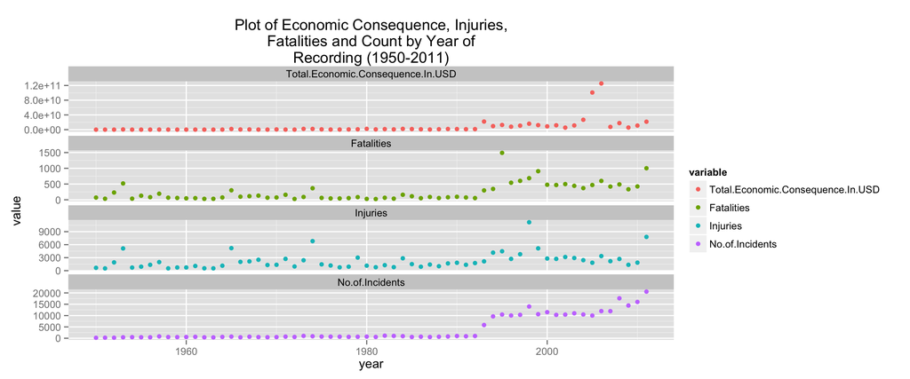

```r
check <- storm.data %>% mutate(year = as.numeric(format(as.Date(BGN_DATE, "%m/%d/%Y %H"),
    "%Y")), ecousd = propdmgusd + cropdmgusd) %>% group_by(year) %>% summarize(Total.Economic.Consequence.In.USD = sum(ecousd),
    Fatalities = sum(FATALITIES), Injuries = sum(INJURIES), No.of.Incidents = n())
dat.m <- melt(check, "year")
p <- ggplot(dat.m, aes(year, value, colour = variable)) + geom_point() + facet_wrap(~variable,
    ncol = 1, scales = "free_y")
p + ggtitle("Plot of Economic Consequence, Injuries,\n Fatalities and Count by Year of \nRecording (1950-2011)")
```

With the above plot windows - it is tempting to disregards the data before 1994 as incidents reported and overall economic damage is low. We can certainly do this when presenting the economic impact, however from the number of fatalities and injuries reported, it is not trivial - so we avoid this option right now. Some analysts will take this approach especially since revisions have happened on the standards and it is likely (but not proven in this analysis) that quality of data may have improved significantly. However for sake of completeness we avoid any more filtering to restrict the observations of interest.

## 3.3 Standardizing Data

### 3.3.1 Crop and Property Damage exponent field standardization

We have already standardized the units of property and crop damage and set new columns for resultant property and crop damage multiplers in previous sections

### 3.3.2 Mapping the Event Type to NOAA standards using Exact Match

The NOAA prescribed values for eventype as present in the code-book Page-6 Table-1 lists 48 distinct values for the Storm event names. As against this we have **444** distinct values in observations.

Before we proceed, we should ease out the subsequent analysis by upper casing all event type and triming it from both sides.

```r
refVector = c("Astronomical Low Tide", "Avalanche", "Blizzard", "Coastal Flood",
    "Cold/Wind Chill", "Debris Flow", "Dense Fog", "Dense Smoke", "Drought",
    "Dust Devil", "Dust Storm", "Excessive Heat", "Extreme Cold/Wind Chill",
    "Flash Flood", "Flood", "Frost/Freeze", "Funnel Cloud", "Freezing Fog",
    "Hail", "Heat", "Heavy Rain", "Heavy Snow", "High Surf", "High Wind", "Hurricane (Typhoon)",
    "Ice Storm", "Lake-Effect Snow", "Lakeshore Flood", "Lightning", "Marine Hail",
    "Marine High Wind", "Marine Strong Wind", "Marine Thunderstorm Wind", "Rip Current",
    "Seiche", "Sleet", "Storm Surge/Tide", "Strong Wind", "Thunderstorm Wind",
    "Tornado", "Tropical Depression", "Tropical Storm", "Tsunami", "Volcanic Ash",
    "Waterspout", "Wildfire", "Winter Storm", "Winter Weather")

ref.events <- data.frame(evtype.std = refVector, evtype.upper = toupper(refVector),
    stringsAsFactors = F)
storm.data <- mutate(storm.data, EVTYPE = trim(toupper(EVTYPE)))

# Very basic fixes to data for expanding abbreviations
storm.data$EVTYPE <- sub("WINDS", "WIND", storm.data$EVTYPE)
storm.data$EVTYPE <- sub("TSTM", "THUNDERSTORM", storm.data$EVTYPE)
storm.data$EVTYPE <- sub("RIVER FLOOD", "FLOOD", storm.data$EVTYPE)
storm.data$EVTYPE <- sub("HAILSTORM", "HAIL", storm.data$EVTYPE)
storm.data$EVTYPE <- sub("^TYPHOON$", "HURRICANE", storm.data$EVTYPE)
storm.data$EVTYPE <- sub("DAMAGING FREEZE", "FROST/FREEZE", storm.data$EVTYPE)
storm.data$EVTYPE <- sub("MAJOR FLOOD", "FLOOD", storm.data$EVTYPE)
storm.data$EVTYPE <- sub("EARLY FROST", "FROST/FREEZE", storm.data$EVTYPE)
storm.data$EVTYPE <- sub("SEVERE THUNDERSTORM", "THUNDERSTORM", storm.data$EVTYPE)
storm.data$EVTYPE <- sub("HIGH WIND/COLD", "HIGH WIND", storm.data$EVTYPE)
storm.data$EVTYPE <- sub("FLOOD/RAIN/WIND", "FLOOD", storm.data$EVTYPE)
storm.data$EVTYPE <- sub("RECORD COLD", "COLD/WIND CHILL", storm.data$EVTYPE)
storm.data$EVTYPE <- sub("FREEZE", "FROST/FREEZE", storm.data$EVTYPE)
storm.data$EVTYPE <- sub("AGRICULTURAL |EROSION/", "", storm.data$EVTYPE)
storm.data$EVTYPE <- sub("RECORD/", "", storm.data$EVTYPE)
storm.data$EVTYPE <- sub("UNSEASONABLY WARM AND DRY|RECORD HEAT", "EXCESSIVE HEAT",
    storm.data$EVTYPE)
# Merge and see the standard matches
matched.data <<- left_join(storm.data, ref.events, by = c(EVTYPE = "evtype.upper"))

# Keep unmatched data in storm.data and only the matched data in
# matched.data
storm.data <- storm.data[is.na(matched.data$evtype.std), ]
matched.data <- matched.data[!is.na(matched.data$evtype.std), ]
first.pass <- nrow(matched.data)
```

By using exact text match we have matched **249058** number of observations leaving **5575** observations to deal with.

### 3.3.3 Matching with Double Metaphones

```r
library(rJava)
.jinit()  # Initialize the JVM
dmp <- .jnew("org.apache.commons.codec.language.DoubleMetaphone")  #should be in classpath
double_metaphone <- function(x) {
    .jcall(dmp, "S", "doubleMetaphone", x)
}  # define a function for Double Metaphone in R

# Generate Metaphones for reference values and remove the ones with
# duplicates
ref.metaphone <- cbind(data.frame(doubleMetaphone = sapply(ref.events$evtype.upper,
    double_metaphone), row.names = NULL, stringsAsFactors = F), ref.events)
to.solve.later <- ref.metaphone[duplicated(ref.metaphone$doubleMetaphone), ]
ref.metaphone <- ref.metaphone[!duplicated(ref.metaphone$doubleMetaphone), ]
```

Of the **48** reference event types provided, there are **2** which have a duplicate metaphone key - so we will take them out of the match else we will get cross-product with data.

```r
# Create a unique list of all remaining event type
evtypes <- unique(storm.data$EVTYPE)
ref.table <- data.frame(cbind(doubleMetaphone = sapply(evtypes, double_metaphone),
    EVTYPE = evtypes))

# Now match the two tables on doubleMetaphone and keep the ones which
# matched
metaphone.match.key <- inner_join(ref.table, ref.metaphone, by = c(doubleMetaphone = "doubleMetaphone")) %>%
    filter(!is.na(evtype.std)) %>% select(EVTYPE, evtype.std, evtype.upper)
```

In the remanining **5575** observations, there are **365** unique event types. We generate their metaphones as well and then join with reference event list with metaphone as the key. There are **185** matches between them. We use the matched metaphones records to populate the correct standard event types (in Mixed and Upper cases) and then add it to the matched list.

```r
more.matches <- left_join(storm.data, metaphone.match.key, by = c(EVTYPE = "EVTYPE"))
storm.data <- storm.data[is.na(more.matches$evtype.std), ]
matched.data <- rbind(matched.data, more.matches %>% filter(!is.na(evtype.std)) %>%
    select(-evtype.upper))
```

Total Standardized Observations for event types is now **251993** leaving **2640** to be standardized. Since this is a very small percentage, we can use the event types as is. As against **47** the remaning data has **180** unique event type values. We just use the pre-existing event type for these remaining rows as standard event type.

```r
matched.data <- rbind(matched.data, mutate(storm.data, evtype.std = EVTYPE))
matched.data$EVTYPE <- as.factor(matched.data$EVTYPE)
matched.data$evtype.std <- as.factor(matched.data$evtype.std)
rm(storm.data, metaphone.match.key, more.matches, ref.table, evtypes, ref.metaphone,
    ref.events, check)
```

Total rows in matched data is now **254633** which is what we started off for the storm data which needed standardization.

# 4 Results

## 4.1 Events which have had maximum impact on Human Health

Human health can be measured from given dataset observations using Fatalities and Injuries columns. They cannot be merged to generate a combined measure of human health impact and therefore we find top-10 event types by fatalities and injuries and see the commonalities

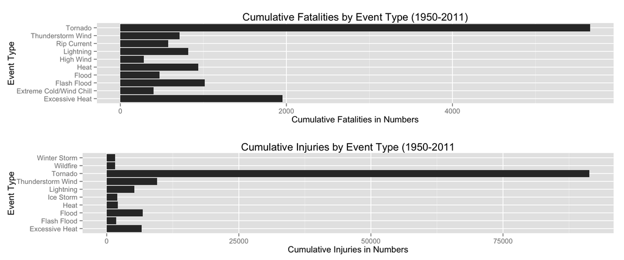

```r
library(grid)
vplayout <- function(x, y) viewport(layout.pos.row = x, layout.pos.col = y)

a <- matched.data %>% filter(FATALITIES > 0) %>% select(evtype.std, FATALITIES) %>%
    group_by(evtype.std) %>% summarize(cnt = n(), total.fatalities = sum(FATALITIES)) %>%
    arrange(desc(total.fatalities)) %>% slice(1:10)

b <- matched.data %>% filter(FATALITIES > 0) %>% select(evtype.std, FATALITIES) %>%
    group_by(evtype.std) %>% summarize(cnt = n(), avg.fatalities = mean(FATALITIES)) %>%
    arrange(desc(avg.fatalities)) %>% slice(1:10)

c <- matched.data %>% filter(INJURIES > 0) %>% select(evtype.std, INJURIES) %>%
    group_by(evtype.std) %>% summarize(cnt = n(), total.injuries = sum(INJURIES)) %>%
    arrange(desc(total.injuries)) %>% slice(1:10)

d <- matched.data %>% filter(INJURIES > 0) %>% select(evtype.std, INJURIES) %>%
    group_by(evtype.std) %>% summarize(cnt = n(), avg.injuries = mean(INJURIES)) %>%
    arrange(desc(avg.injuries)) %>% slice(1:10)


a1 <- ggplot(a, aes(x = evtype.std, y = total.fatalities)) + geom_bar(stat = "identity") +
    ggtitle("Cumulative Fatalities by Event Type (1950-2011)") + xlab("Event Type") +
    ylab("Cumulative Fatalities in Numbers") + coord_flip()

c1 <- ggplot(c, aes(x = evtype.std, y = total.injuries)) + geom_bar(stat = "identity") +
    ggtitle("Cumulative Injuries by Event Type (1950-2011") + xlab("Event Type") +
    ylab("Cumulative Injuries in Numbers") + coord_flip()

pushViewport(viewport(layout = grid.layout(2, 1)))  # Define layout
print(a1, vp = vplayout(1, 1))
print(c1, vp = vplayout(2, 1))
```

From the above, it is clear that as a total, The **top-3 events that have had maximum cumulative fatalities in US** are

```r
slice(a, 1:3) %>% select(evtype.std, total.fatalities)
```

```
## Source: local data frame [3 x 2]
##
##       evtype.std total.fatalities
## 1        Tornado             5658
## 2 Excessive Heat             1953
## 3    Flash Flood             1018
```

From the above, it is clear that as a total, The **top-3 events that have had maximum cumulative injuries in US** are

```r
slice(c, 1:3) %>% select(evtype.std, total.injuries)
```

```
## Source: local data frame [3 x 2]
##
##          evtype.std total.injuries
## 1           Tornado          91364
## 2 Thunderstorm Wind           9509
## 3             Flood           6791
```

It should be pointed out that following events figure in top-10 of **both cumulative Injuries and Fatalities impact** -

```r
intersect(a$evtype.std, c$evtype.std)
```

```
## [1] "Tornado"           "Excessive Heat"    "Flash Flood"
## [4] "Heat"              "Lightning"         "Thunderstorm Wind"
## [7] "Flood"
```

Following events **only figure in top-10 by cumulative fatalities** so far between 1950 and 2011 -

```r
setdiff(a$evtype.std, c$evtype.std)
```

```
## [1] "Rip Current"             "Extreme Cold/Wind Chill"
## [3] "High Wind"
```

Following events **only figure in top-10 by cumulative injuries** between 1950 and 2011 -

```r
setdiff(c$evtype.std, a$evtype.std)
```

```
## [1] "Ice Storm"    "Wildfire"     "Winter Storm"
```

```r
slice(b, 1:3) %>% select(evtype.std, avg.fatalities)
```

```
## Source: local data frame [3 x 2]
##
##            evtype.std avg.fatalities
## 1             Tsunami      16.500000
## 2 Tropical Depression       8.000000
## 3           HEAT WAVE       6.615385
```

```r
slice(d, 1:3) %>% select(evtype.std, avg.injuries)
```

```
## Source: local data frame [3 x 2]
##
##   evtype.std avg.injuries
## 1    Tsunami    129.00000
## 2       Heat     45.65217
## 3      Flood     43.25478
```

## 4.2 Events which have had maximum Economic Consequences

Economic consequences within the dataset can be assessed by summing up the damages to property and crop. This is not to say that loss of life and injuries will not have economic consequences, but their quantification is much harder to add within the economic consuequences directly. Answering this questions will require us to plot both the 1. Cumulative damage by events as well as 2. The average magnitude of each event to understand as a whole which events have had most severe economic consequence as well as in case an event happens, what is the typical economic damage expected.

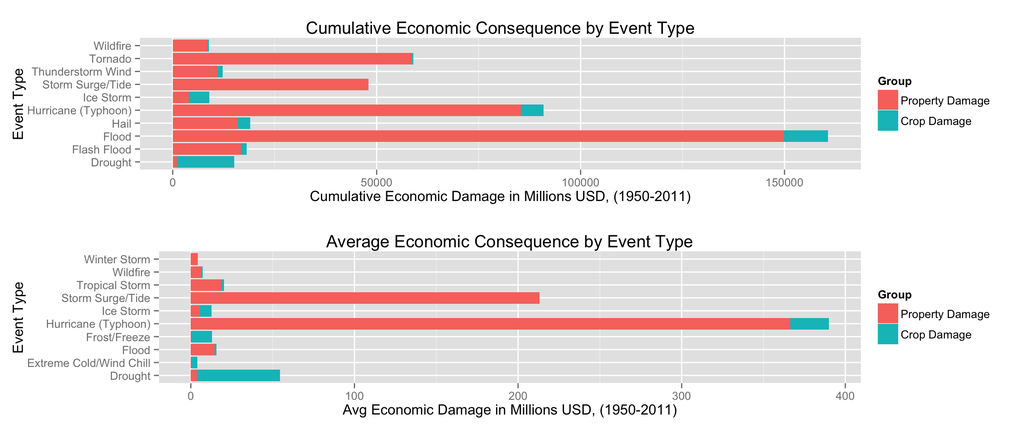

```r
library(grid)
vplayout <- function(x, y) viewport(layout.pos.row = x, layout.pos.col = y)

x <- matched.data %>% select(evtype.std, cropdmgusd, propdmgusd) %>% group_by(evtype.std) %>%
    summarize(cnt = n(), total.dmg = sum(cropdmgusd + propdmgusd), propmusd = sum(propdmgusd)/1e+06,
        cropmusd = sum(cropdmgusd)/1e+06) %>% arrange(desc(total.dmg)) %>% slice(1:10)

eco.dmg.sum <- x %>% select(evtype.std, propmusd, cropmusd) %>% gather(damage.type,
    damage.usd, propmusd:cropmusd)

y <- matched.data %>% select(evtype.std, cropdmgusd, propdmgusd) %>% group_by(evtype.std) %>%
    summarize(cnt = n(), avg.dmg = mean(cropdmgusd + propdmgusd), propmusd = mean(propdmgusd)/1e+06,
        cropmusd = mean(cropdmgusd)/1e+06) %>% filter(cnt > 100) %>% arrange(desc(avg.dmg)) %>%
    slice(1:10)

eco.dmg.avg <- y %>% select(evtype.std, propmusd, cropmusd) %>% gather(damage.type,
    damage.usd, propmusd:cropmusd)

q1 <- ggplot(eco.dmg.sum, aes(x = evtype.std, y = damage.usd, fill = damage.type)) +
    geom_bar(stat = "identity") + ggtitle("Cumulative Economic Consequence by Event Type") +
    xlab("Event Type") + ylab("Cumulative Economic Damage in Millions USD, (1950-2011)") +
    scale_fill_discrete(name = "Group", label = c("Property Damage", "Crop Damage")) +
    coord_flip()

q2 <- ggplot(eco.dmg.avg, aes(x = evtype.std, y = damage.usd, fill = damage.type)) +
    geom_bar(stat = "identity") + ggtitle("Average Economic Consequence by Event Type") +
    xlab("Event Type") + ylab("Avg Economic Damage in Millions USD, (1950-2011)") +
    scale_fill_discrete(name = "Group", label = c("Property Damage", "Crop Damage")) +
    coord_flip()

pushViewport(viewport(layout = grid.layout(2, 1)))  # Define layout
print(q1, vp = vplayout(1, 1))
print(q2, vp = vplayout(2, 1))
```

From the above, it is clear that as a total, The top-3 events that have had maximum cumulative damage in US are

```r
slice(x, 1:3) %>% select(evtype.std, total.dmg)
```

```
## Source: local data frame [3 x 2]
##
##            evtype.std    total.dmg
## 1               Flood 160685882757
## 2 Hurricane (Typhoon)  90872527810
## 3             Tornado  58959393949
```

```r
slice(y, 1:3) %>% select(evtype.std, avg.dmg)
```

```
## Source: local data frame [3 x 2]
##
##            evtype.std   avg.dmg
## 1 Hurricane (Typhoon) 390010849
## 2    Storm Surge/Tide 213181240
## 3             Drought  54415499
```

It should be pointed out that following events figure in top-10 of **both cumulative and by average-per-instance impact**.

```r
intersect(x$evtype.std, y$evtype.std)
```

```
## [1] "Flood"               "Hurricane (Typhoon)" "Storm Surge/Tide"
## [4] "Drought"             "Ice Storm"           "Wildfire"
```

Following events **only figure in top-10 by cumulative damage** so far between 1950 and 2011 -

```r
setdiff(x$evtype.std, y$evtype.std)
```

```
## [1] "Tornado"           "Hail"              "Flash Flood"
## [4] "Thunderstorm Wind"
```

Following events **only figure in top-10 by average impact** and not by their aggregate impact so far -

```r
setdiff(y$evtype.std, x$evtype.std)
```

```
## [1] "Tropical Storm"          "Frost/Freeze"
## [3] "Winter Storm"            "Extreme Cold/Wind Chill"
```